# R Notebook for Unit 3

Exploration of the Principles of Statistical Inference

# Load libraries

```r
library(tidyverse)
library(descriptr)
library(mosaic)
```

# Import data

```r
wtloss <- read_csv(file = "wtloss.csv")
#screener(wtloss)
```

# Explore the sample data

## Get descriptive statistics for lbslost (pounds lost)

```r
summary_stats(wtloss$lbslost)
```

[output not shown]

## Make a histogram of lbslost

### Start by marking +/- 2 SDs from mean

```r
mean(wtloss$lbslost) - 2*sd(wtloss$lbslost)
```

```
[1] -1.132875
```

```r
mean(wtloss$lbslost) + 2*sd(wtloss$lbslost)
```

```
[1] 7.259857
```

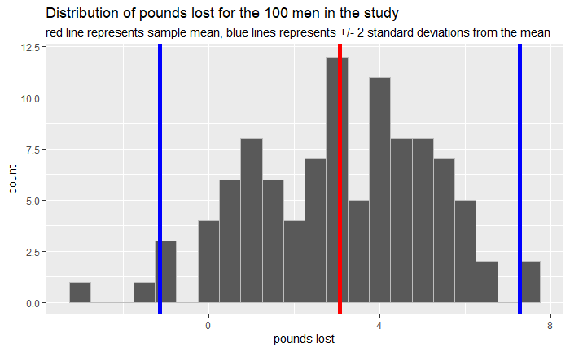

```r
ggplot(wtloss, aes(x = lbslost)) +
  geom_histogram(binwidth = .5, color = "grey") +
  geom_vline(xintercept = mean(wtloss$lbslost), lwd = 2, color="red") +
  geom_vline(xintercept = mean(wtloss$lbslost) + 2*sd(wtloss$lbslost), lwd = 2, color="blue") +
  geom_vline(xintercept = mean(wtloss$lbslost) - 2*sd(wtloss$lbslost), lwd = 2, color="blue") +
  labs(title = "Distribution of pounds lost for the 100 men in the study",
       subtitle = "red line represents sample mean, blue lines represents +/- 2 standard deviations from the mean",
       x = "pounds lost")
```

```r
NA
```

### Repeat the histogram, but exchange 2 for 1.96, the more precise estimate of t-scores

```r
qnorm(c(.025, .975))
```

```
[1] -1.959964  1.959964
```

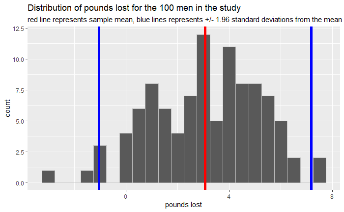

```r
ggplot(wtloss, aes(x = lbslost)) +
  geom_histogram(binwidth = .5, color = "grey") +
  geom_vline(xintercept = mean(wtloss$lbslost), lwd = 2, color="red") +
  geom_vline(xintercept = mean(wtloss$lbslost) + 1.959964*sd(wtloss$lbslost), lwd = 2, color="blue") +
  geom_vline(xintercept = mean(wtloss$lbslost) - 1.959964*sd(wtloss$lbslost), lwd = 2, color="blue") +
  labs(title = "Distribution of pounds lost for the 100 men in the study",
       subtitle = "red line represents sample mean, blue lines represents +/- 1.96 standard deviations from the mean",
       x = "pounds lost")
```

```r
NA
```

### Repeat the histogram, but now make use of the Student’s t-distribution instead of the z-distribution

```r
qt(c(.025, .975), df = 99)
```

```
[1] -1.984217  1.984217
```

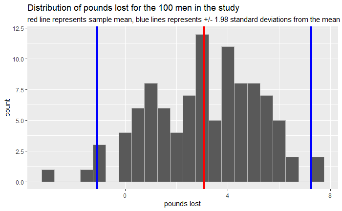

```r
ggplot(wtloss, aes(x = lbslost)) +
  geom_histogram(binwidth = .5, color = "grey") +
  geom_vline(xintercept = mean(wtloss$lbslost), lwd = 2, color="red") +
  geom_vline(xintercept = mean(wtloss$lbslost) + 1.984217*sd(wtloss$lbslost), lwd = 2, color="blue") +
  geom_vline(xintercept = mean(wtloss$lbslost) - 1.984217*sd(wtloss$lbslost), lwd = 2, color="blue") +
  labs(title = "Distribution of pounds lost for the 100 men in the study",
       subtitle = "red line represents sample mean, blue lines represents +/- 1.98 standard deviations from the mean",
       x = "pounds lost")
```

```r
NA
```

# Consider the hypothetical population

## Simulate a population

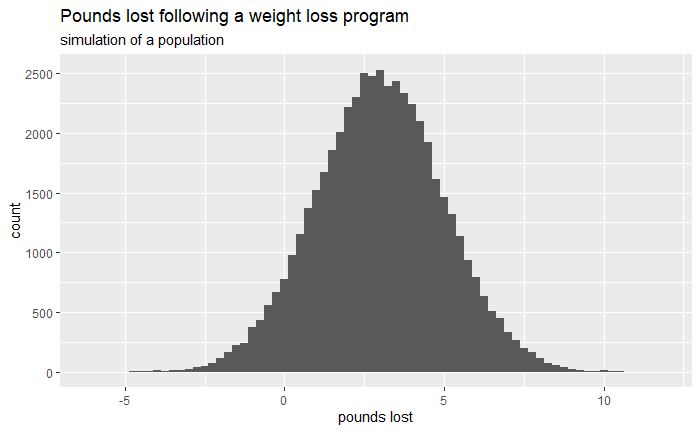

```r
# generate some data
set.seed(8642)
p_lbslost <- rnorm(n=50000, m=3.00, sd=2.00)
my_pop <- data.frame(p_lbslost)
# plot the normal distribution
ggplot(my_pop, aes(x = p_lbslost)) +
  geom_histogram(binwidth = .25) +
  labs(title = "Pounds lost following a weight loss program", subtitle = "simulation of a population", x = "pounds lost")
```

# Consider a uniform distribution of the underlying variable in the population

## Simulate a population

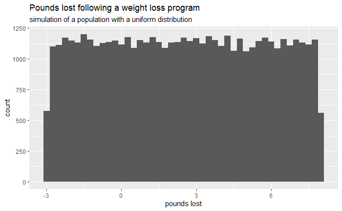

```r
library(tidyverse)
# generate some data
p_lbslost <- runif(n=50000, min = -3, max = 8)
my_pop <- data.frame(p_lbslost)
# plot the uniform distribution
ggplot(my_pop, aes(x = p_lbslost)) +
  geom_histogram(binwidth = .25) +
  labs(title = "Pounds lost following a weight loss program", subtitle = "simulation of a population with a uniform distribution", x = "pounds lost")
```

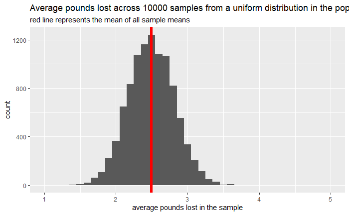

```r
# function to randomly sample from the population
rep_sample_n <- function(tbl, size, replace = FALSE, reps = 1)
{
    n <- nrow(tbl)
    i <- unlist(replicate(reps, sample.int(n, size, replace = replace), simplify = FALSE))
    rep_tbl <- cbind(replicate = rep(1:reps,rep(size,reps)), tbl[i, , drop=FALSE])
    dplyr::group_by(rep_tbl, replicate)
}
sample_means <- my_pop %>%
  rep_sample_n(size = 100, reps = 10000, replace = TRUE) %>%
  summarize(mean_lbslost = mean(p_lbslost), sd_lbslost = sd(p_lbslost))
ggplot(sample_means, aes(x = mean_lbslost)) +
  geom_histogram(binwidth = .1) +
  geom_vline(xintercept = mean(sample_means$mean_lbslost), lwd = 2, color="red") +
  labs(title = "Average pounds lost across 10000 samples from a uniform distribution in the population",
       subtitle = "red line represents the mean of all sample means", x = "average pounds lost in the sample") +
  scale_x_continuous(limits = c(1, 5))
```

## Randomly select 3 samples of size 100 from the my_pop population

```r
set.seed(19657)
s1 <- sample_n(my_pop, 100, replace = TRUE)
s2 <- sample_n(my_pop, 100, replace = TRUE)
s3 <- sample_n(my_pop, 100, replace = TRUE)
my_samples <- bind_rows(s1, s2, s3, .id='sample')
my_samples %>%
  group_by(sample) %>%
  summarize(mean_in_sample = mean(p_lbslost))
```

| sample | mean_in_sample |
| --- | --- |
| 1 | 2.293243 |
| 2 | 2.695691 |
| 3 | 2.297306 |

## Plot the distribution of pounds lost in each of the samples

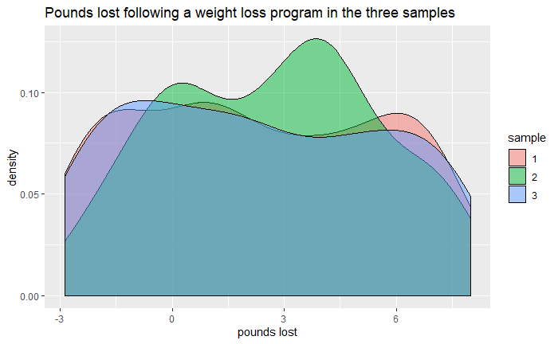

```r
ggplot(my_samples, aes(x = p_lbslost, group = sample, fill = sample)) +
  geom_density(alpha = .5) +
  labs(title = "Pounds lost following a weight loss program in the three samples", x = "pounds lost")
```

## Create a repeated sampling function

```r
rep_sample_n <- function(tbl, size, replace = FALSE, reps = 1)
{
    n <- nrow(tbl)
    i <- unlist(replicate(reps, sample.int(n, size, replace = replace), simplify = FALSE))
    rep_tbl <- cbind(replicate = rep(1:reps,rep(size,reps)), tbl[i, , drop=FALSE])
    dplyr::group_by(rep_tbl, replicate)
}
```

## Draw 10000 random samples and obtain the mean and standard deviation in each one

### Start with a sample size equal to the wtloss dataframe (100 men per sample)

#### Generate the samples

```r
set.seed(47256)
sample_means <- my_pop %>%
  rep_sample_n(size = 100, reps = 10000, replace = TRUE) %>%
  summarize(mean_lbslost = mean(p_lbslost), sd_lbslost = sd(p_lbslost))
# print mean and standard deviation of average pounds lost
mean(sample_means$mean_lbslost)
```

```
[1] 2.494432
```

```r
sd(sample_means$mean_lbslost)
```

```
[1] 0.3223946
```

#### Plot the average pounds lost in each of the 10000 random samples of size 100

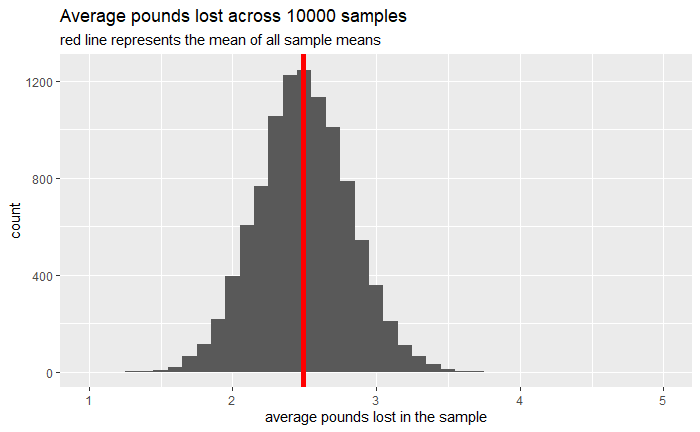

```r
ggplot(sample_means, aes(x = mean_lbslost)) +
  geom_histogram(binwidth = .1) +
  geom_vline(xintercept = mean(sample_means$mean_lbslost), lwd = 2, color="red") +
  labs(title = "Average pounds lost across 10000 samples",
       subtitle = "red line represents the mean of all sample means", x = "average pounds lost in the sample") +
  scale_x_continuous(limits = c(1, 5))
```

#### Calculate the number of samples that have a mean outside +/- 1.98 standard deviations from the mean

```r
me <- 1.984217*0.2002739 # margin of error
lower <- 2.985371 - (1.984217*0.2002739) # lower bound of confidence limit
upper <- 2.985371 + (1.984217*0.2002739) # upper bound of confidence limit
me
```

```
[1] 0.3973869
```

```r
lower
```

```
[1] 2.587984
```

```r
upper
```

```
[1] 3.382758
```

```r
sample_means <- sample_means %>%
  mutate(out_range = ifelse(mean_lbslost < lower | mean_lbslost > upper, 1, 0))
mean(sample_means$out_range)
```

```
[1] 0.6223
```

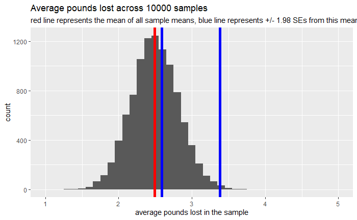

```r
# add 95% confidence band to our histogram
ggplot(sample_means, aes(x = mean_lbslost)) +
  geom_histogram(binwidth = .1) +
  geom_vline(xintercept = mean(sample_means$mean_lbslost), lwd = 2, color="red") +
  geom_vline(xintercept = lower, lwd = 2, color="blue") +
  geom_vline(xintercept = upper, lwd = 2, color="blue") +
  labs(title = "Average pounds lost across 10000 samples",
       subtitle = "red line represents the mean of all sample means, blue line represents +/- 1.98 SEs from this mean",
       x = "average pounds lost in the sample") +
  scale_x_continuous(limits = c(1, 5))
```

```r
# remove these temporary quantities
rm(me, lower, upper)
```

### Explore what happens when we change the sample size

```r
samp.size <- 25
explore <- my_pop %>%
  rep_sample_n(size = samp.size, reps = 10000, replace = TRUE) %>%
  summarize(mean_lbslost = mean(p_lbslost), sd_lbslost = sd(p_lbslost))
# print mean and standard deviation of average pounds lost
mean(explore$mean_lbslost)
```

```
[1] 2.485518
```

```r
sd(explore$mean_lbslost)
```

```
[1] 0.6301774
```

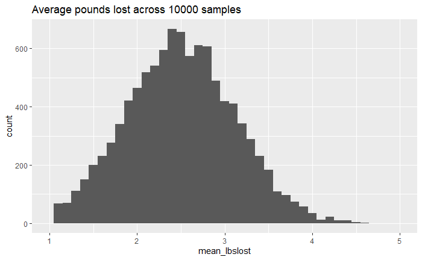

```r
ggplot(explore, aes(x = mean_lbslost)) +
  geom_histogram(binwidth = .1) +
  labs(title = "Average pounds lost across 10000 samples") +
  scale_x_continuous(limits = c(1, 5))
```